# Linear Regression - Example Project

Marina Wyss

8/17/2019

```r
knitr::opts_chunk$set(echo = TRUE)

library(ggplot2)
library(readr)
library(dplyr)
library(GGally)
library(kableExtra)
library(caTools)
library(stargazer)
```

# Linear Regression - Example Project

Imagine that you’ve just got some contract work with an e-commerce company that sells clothing online, but they also have in-store style and clothing advice sessions. Customers come in to the store, have sessions/meetings with a personal stylist, then they can go home and order either on a mobile app or website for the clothes they want.

The company is trying to decide whether to focus their efforts on their mobile app experience or their website.

The data is obviously fake, and this example is heavily inspired by Pierian Data’s Python course on Udemy.

## Get the Data & Take a Look

```r
# read in the Ecommerce Customers csv file as a DataFrame called customers.
customers <- read_csv("Ecommerce Customers")
```

We’ll work with the Ecommerce Customers csv file from the company. It has customer info, such as email, address, and their color avatar. Then it also has numerical value columns:

- Avg. Session Length: Average session of in-store style advice sessions.
- Time on App: Average time spent on App in minutes
- Time on Website: Average time spent on Website in minutes
- Length of Membership: How many years the customer has been a member.

```r
head(customers)
```

```
## # A tibble: 6 x 8
##   Email Address Avatar `Avg. Session L… `Time on App` `Time on Websit…
##   <chr> <chr>   <chr>             <dbl>         <dbl>            <dbl>
## 1 mste… "835 F… Violet             34.5          12.7             39.6
## 2 hduk… "4547 … DarkG…             31.9          11.1             37.3
## 3 pall… "24645… Bisque             33.0          11.3             37.1
## 4 rive… "1414 … Saddl…             34.3          13.7             36.7
## 5 mste… "14023… Mediu…             33.3          12.8             37.5
## 6 alva… "645 M… Flora…             33.9          12.0             34.5
## # … with 2 more variables: `Length of Membership` <dbl>, `Yearly Amount
## #   Spent` <dbl>
```

```r
summary(customers)
```

```
##     Email             Address             Avatar
##  Length:500         Length:500         Length:500
##  Class :character   Class :character   Class :character
##  Mode  :character   Mode  :character   Mode  :character
##
##
##
##  Avg. Session Length  Time on App     Time on Website Length of Membership
##  Min.   :29.53       Min.   : 8.508   Min.   :33.91   Min.   :0.2699
##  1st Qu.:32.34       1st Qu.:11.388   1st Qu.:36.35   1st Qu.:2.9304
##  Median :33.08       Median :11.983   Median :37.07   Median :3.5340
##  Mean   :33.05       Mean   :12.052   Mean   :37.06   Mean   :3.5335
##  3rd Qu.:33.71       3rd Qu.:12.754   3rd Qu.:37.72   3rd Qu.:4.1265
##  Max.   :36.14       Max.   :15.127   Max.   :40.01   Max.   :6.9227
##  Yearly Amount Spent
##  Min.   :256.7
##  1st Qu.:445.0
##  Median :498.9
##  Mean   :499.3
##  3rd Qu.:549.3
##  Max.   :765.5
```

```r
str(customers)
```

```
## Classes 'spec_tbl_df', 'tbl_df', 'tbl' and 'data.frame': 500 obs. of  8 variables:
##  $ Email               : chr  "mstephenson@fernandez.com" "hduke@hotmail.com" "pallen@yahoo.com" "riverarebecca@gmail.com" ...
##  $ Address             : chr  "835 Frank Tunnel\nWrightmouth, MI 82180-9605" "4547 Archer Common\nDiazchester, CA 06566-8576" "24645 Valerie Unions Suite 582\nCobbborough, DC 99414-7564" "1414 David Throughway\nPort Jason, OH 22070-1220" ...
##  $ Avatar              : chr  "Violet" "DarkGreen" "Bisque" "SaddleBrown" ...
##  $ Avg. Session Length : num  34.5 31.9 33 34.3 33.3 ...
##  $ Time on App         : num  12.7 11.1 11.3 13.7 12.8 ...
##  $ Time on Website     : num  39.6 37.3 37.1 36.7 37.5 ...
##  $ Length of Membership: num  4.08 2.66 4.1 3.12 4.45 ...
##  $ Yearly Amount Spent : num  588 392 488 582 599 ...
##  - attr(*, "spec")=
##   .. cols(
##   ..   Email = col_character(),
##   ..   Address = col_character(),
##   ..   Avatar = col_character(),
##   ..   `Avg. Session Length` = col_double(),
##   ..   `Time on App` = col_double(),
##   ..   `Time on Website` = col_double(),
##   ..   `Length of Membership` = col_double(),
##   ..   `Yearly Amount Spent` = col_double()
##   .. )
```

```r
# checking if we have any NA values
any(is.na(customers))
```

```
## [1] FALSE
```

## Data Manipulation/Clean-up

Let’s drop the unused columns. This isn’t necessary, let’s just do it for practice.

```r
customers <- customers %>% select(-Email, -Address, -Avatar)
```

Then, let’s change the column names to get rid of the spaces. They are annoying in R.

```r
customers <- customers %>%
  rename(
    avgSessionLength = 'Avg. Session Length',
    timeOnApp = 'Time on App',
    timeOnWebsite = 'Time on Website',
    lengthOfMembership = 'Length of Membership',
    yearlyAmountSpent =  'Yearly Amount Spent'
    )
```

Since we don’t have any categorical data, let’s create a new column for gender. Here we create a new column that has gender as a factor of Male and Female, with 40% men and 60% women.

```r
customers$Gender <- as.factor(sample(c("Female", "Male"),
                                     size = length(customers$yearlyAmountSpent),
                                     replace = TRUE,
                                     prob = c(0.60, 0.40)))
```

Just to make it interesting, let’s change their spending behaviors a bit.

```r
customers$yearlyAmountSpent <- ifelse(customers$`Gender` == 'Male',
       customers$yearlyAmountSpent * 0.75,
       customers$yearlyAmountSpent)

customers$lengthOfMembership <- ifelse(customers$`Gender` == 'Male',
       customers$lengthOfMembership * 1.10,
       customers$lengthOfMembership)

customers$timeOnApp <- ifelse(customers$`Gender` == 'Male',
       customers$timeOnApp * 0.85,
       customers$timeOnApp)

# checking that it worked
kable(customers %>% group_by(Gender) %>% summarise_all("mean")) %>% kable_styling()
```

| Gender | avgSessionLength | timeOnApp | timeOnWebsite | lengthOfMembership | yearlyAmountSpent |
| --- | --- | --- | --- | --- | --- |
| Female | 33.02094 | 12.03898 | 37.00812 | 3.528018 | 497.4291 |
| Male | 33.10627 | 10.26351 | 37.14654 | 3.896660 | 376.8118 |

## Exploratory Data Analysis

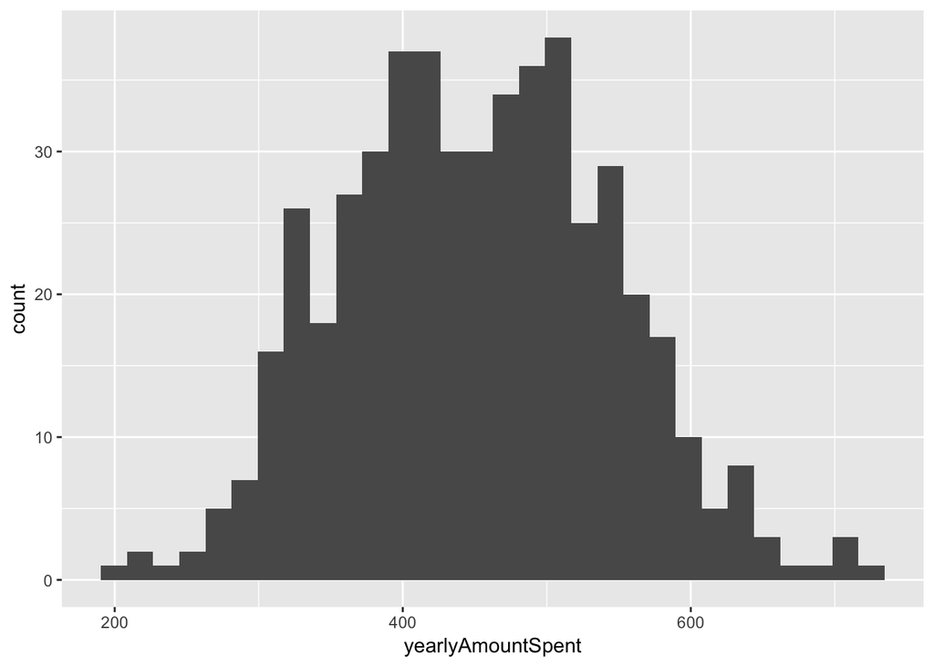

```r
# is y close to normally distributed?
ggplot(customers, aes(x = yearlyAmountSpent)) + geom_histogram()
```

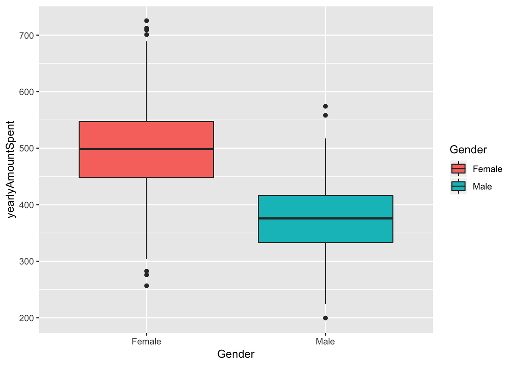

```r
# outliers?
ggplot(customers, aes(x = Gender, y = yearlyAmountSpent)) + geom_boxplot(aes(fill = Gender))
```

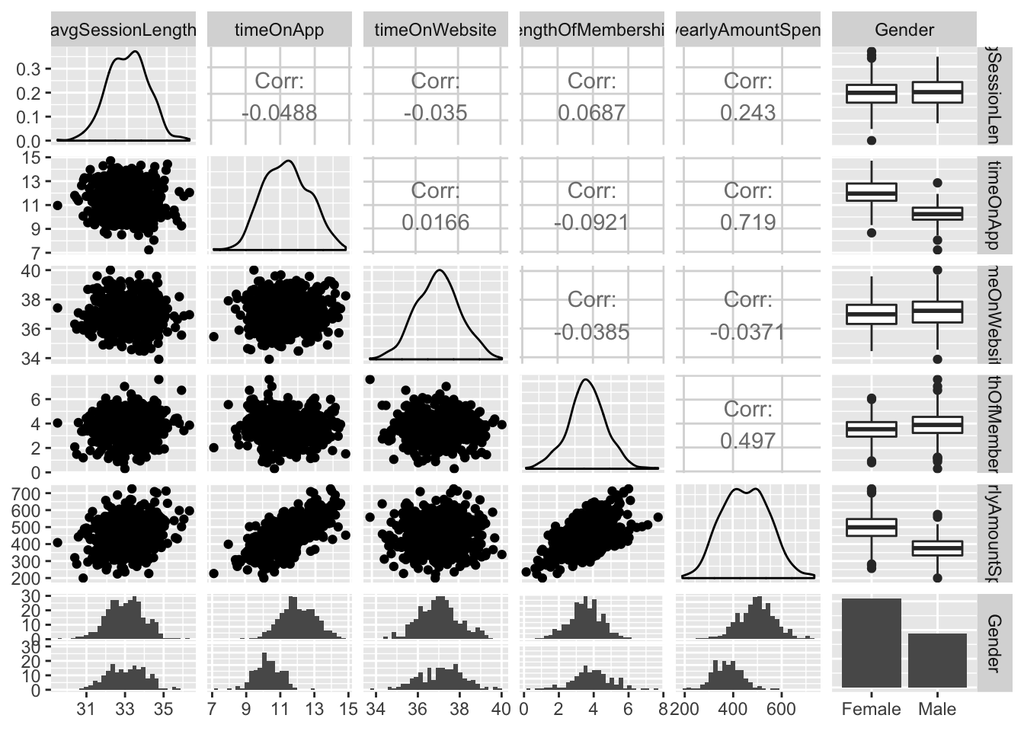

```r
ggpairs(customers)
```

Length of Membership and Time on App seem to be the most relevant factors. Let’s investigate a bit more.

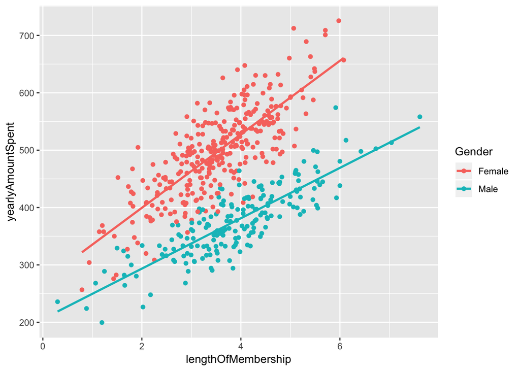

```r
ggplot(customers, aes(x = lengthOfMembership, y = yearlyAmountSpent, color = Gender)) +
  geom_point() +
  geom_smooth(method = 'lm', se = FALSE)
```

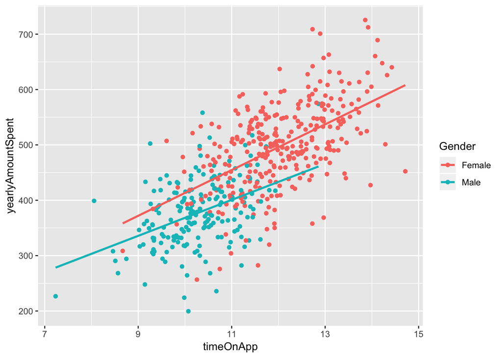

```r
ggplot(customers, aes(x = timeOnApp, y = yearlyAmountSpent, color = Gender)) +
  geom_point() +
  geom_smooth(method = 'lm', se = FALSE)
```

## Training and Test Data

```r
# set a random see so your "random" results are the same as mine
set.seed(101)

# split up the sample, basically randomly assigns a booleans to a new column "sample"
sample <- sample.split(customers$yearlyAmountSpent, SplitRatio = 0.70)

# training Data
train = subset(customers, sample == TRUE)

# testing Data
test = subset(customers, sample == FALSE)
```

Now, it’s time to model our data!

```r
# we create the model using training data
model <- lm(yearlyAmountSpent ~ avgSessionLength + timeOnApp + timeOnWebsite + lengthOfMembership + Gender, data = train)
```

## Prediction

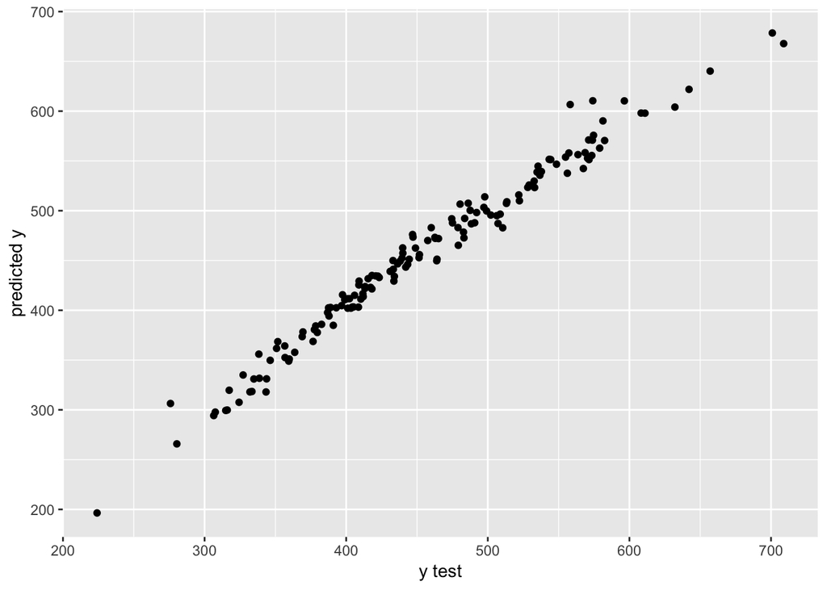

```r
predictions <- predict(model, test)

ggplot(test, aes(x = yearlyAmountSpent, y = predictions)) +
  geom_point() +
  labs(y = "predicted y", x = "y test")
```

Our model is doing very well! It would be a completely straight line with the points on top of each other if it was perfect.

## Model Evaluation

Let’s evaluate our model performance by calculating the residual sum of squares and the explained variance score (R-squared).

```r
results <- cbind(predictions, test$yearlyAmountSpent)
colnames(results) <- c('pred','real')
results <- as.data.frame(results)

mse <- mean((results$real-results$pred)^2)

print(paste0("MSE: ", mse))
```

```
## [1] "MSE: 192.652071264044"
```

```r
print(paste0("RMSE: ", mse^0.5))
```

```
## [1] "RMSE: 13.8799161115636"
```

Then, let’s plot the residuals.

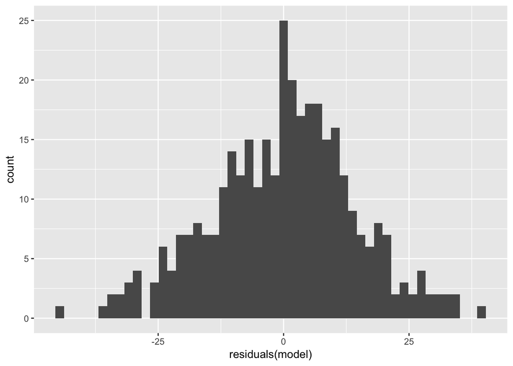

```r
res <- as.data.frame(residuals(model))

ggplot(res, aes(x = residuals(model))) +  geom_histogram(bins = 50)
```

Our residuals look normally distributed. Hooray.

## Interpretation

Since we know our model is looking good, let’s take a stab at evaluating our model:

```r
stargazer(model,
          type = "html",
          intercept.bottom = FALSE)
```

|  | *Dependent variable:* |
| --- | --- |
|  | yearlyAmountSpent |
| Constant | -953.529*** |
|  | (39.584) |
| avgSessionLength | 23.244*** |
|  | (0.780) |
| timeOnApp | 37.780*** |
|  | (0.813) |
| timeOnWebsite | 1.209 |
|  | (0.770) |
| lengthOfMembership | 52.114*** |
|  | (0.730) |
| GenderMale | -74.011*** |
|  | (2.239) |
| Observations | 350 |
| R<sup>2</sup> | 0.977 |
| Adjusted R<sup>2</sup> | 0.977 |
| Residual Std. Error | 14.382 (df = 344) |
| F Statistic | 2,922.357*** (df = 5; 344) |
| *Note:* | p<0.1; p<0.05; p<0.01 |

Interpreting the coefficients: